# GGplot2 Extension

David Asare Kumi

4/13/2020

## The Grammar

### Introduction

- In order to unlock the full power of ggplot2, you’ll need to master the underlying grammar. By understanding the grammar, and how its components fit together, you can create a wider range of visualizations, combine multiple sources of data, and customise to your heart’s content.

### Building a Scatterplot

- How are engine size and fuel economy related? We might create a scatterplot of engine displacement and highway mpg with points coloured by number of cylinders:

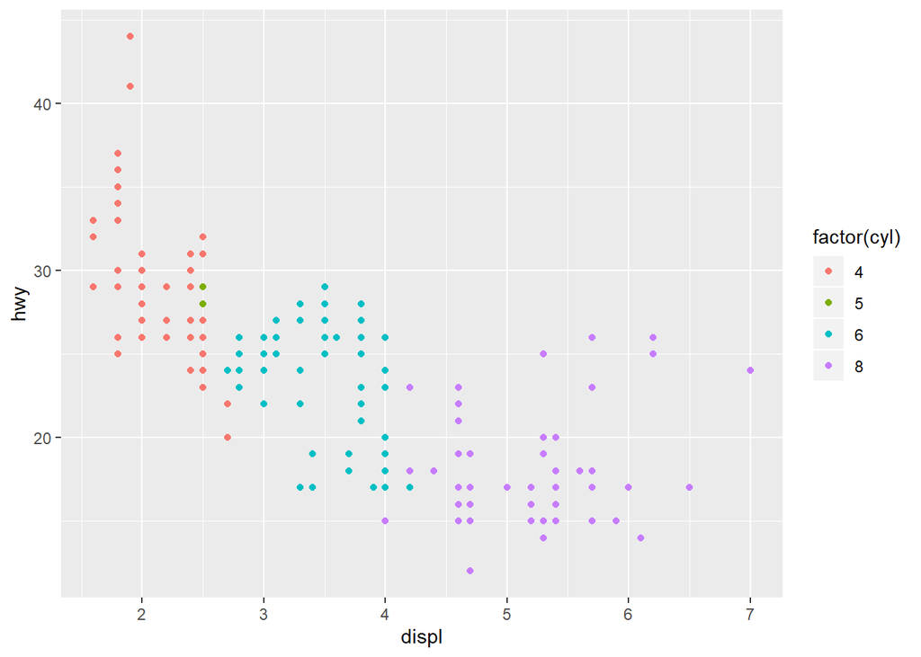

```r
library(ggplot2)
library(dplyr)
library(gridExtra)
library(mgcv)
library(MASS)
library(directlabels)

ggplot(mpg, aes(displ, hwy, colour = factor(cyl))) + geom_point()
```

- You can create plots like this easily, but what is going on underneath the surface? How does ggplot2 draw this plot?